# How Can a Wellness Technology Company Play It Smart?

Ashley

2024-06-09

## Overview

This is a case study from [Google Data Analytics Certificate](https://grow.google/certificates/en_uk/certificates/data-analytics).

This repository will break down into different section according to the step of data analysis process:

1. Ask
2. Prepare
3. Process
4. Analyse
5. Share
6. Act

Process, Analyse, Share and Act will be focused in this document.

## Process Stage

### Load libraries

In this case study, the following libraries will be used:

- `readr`
- `tidyverse`
- `skimr`
- `snakecase`
- `showtext`

```r
# Loading packages

library(readr)
library(tidyverse)
library(skimr)
library(snakecase)
library(showtext)
# Adding Roboto Font from Google

font_add_google("Roboto", family = "roboto")
showtext_auto()
```

### Import data

The data have been saved into 2 different directories with 2 different time frame. Csv file that are interested from directories will be imported into R with `_1` and `_2` suffix for merging.

```r
# Get directories of file from different time frames
first_dir = (
  "./mturkfitbit_export_3.12.16-4.11.16/Fitabase Data 3.12.16-4.11.16/")
second_dir = (
  "./mturkfitbit_export_4.12.16-5.12.16/Fitabase Data 4.12.16-5.12.16/")

# Limit csv file with interested data loaded

csv_interested = c(
  "dailyActivity_merged",
  "heartrate_seconds_merged",
  "minuteCaloriesNarrow_merged",
  "minuteIntensitiesNarrow_merged",
  "minuteMETsNarrow_merged",
  "minuteSleep_merged",
  "minuteStepsNarrow_merged",
  "weightLogInfo_merged"
)

# Import data from two directories and rename data frames

for (i in first_dir) {
  for (csv_name in csv_interested) {
    tmp <- readr::read_csv(file = stringr::str_c(i, csv_name,".csv"))
    obj_name <- stringr::str_c(
      stringr::str_replace(
        csv_name, "_merged", "")
      ,"_1"
    )
    base::assign(obj_name, tmp)
  }
}
for (i in second_dir) {
  for (csv_name in csv_interested) {
    tmp <- readr::read_csv(file = stringr::str_c(i, csv_name,".csv"))
    obj_name <- stringr::str_c(
      stringr::str_replace(
        csv_name, "_merged", "")
      ,"_2"
    )
    base::assign(obj_name, tmp)
  }
}
```

### Merge data

Merging data from 2 different time frames into a data frame for ease of later steps.

```r
daily_activity <- base::rbind(dailyActivity_1,
                              dailyActivity_2)
heartrate_seconds <- base::rbind(heartrate_seconds_1,
                                 heartrate_seconds_2)
minute_calories <- base::rbind(minuteCaloriesNarrow_1,
                               minuteCaloriesNarrow_2)
minute_intensities <- base::rbind(minuteIntensitiesNarrow_1,
                                  minuteIntensitiesNarrow_2)
minute_METs <- base::rbind(minuteMETsNarrow_1,
                           minuteMETsNarrow_2)
minute_sleep <- base::rbind(minuteSleep_1,
                            minuteSleep_2)
minute_steps <- base::rbind(minuteStepsNarrow_1,
                            minuteStepsNarrow_2)
weight_log_info <- base::rbind(weightLogInfo_1,
                               weightLogInfo_2)

# Checking dimensions of the merged data frame
nrow(daily_activity)
```

```
## [1] 1397
```

```r
nrow(dailyActivity_1) + nrow(dailyActivity_2)
```

```
## [1] 1397
```

The dimension of the merged data frame is the combination of the 2 original data frames.

### Transform and Clean Date and Date Time column

In the original data set, the column name ‘date’ and ‘time’ are used interchangeably and other column name like ‘ActivityDate’ are used. ‘date’ and ‘date_time’ will be used in the data frame for consistency.

Date and date_time column are mutate to be treated as date and datetime column.

```r
daily_activity <- daily_activity %>%
  rename(date = ActivityDate) %>%
  mutate(date = as_date(date, format = "%m/%d/%Y"))

heartrate_seconds <- heartrate_seconds %>%
  rename(date_time = Time) %>%
  mutate(date_time = as_datetime(date_time, format = "%m/%d/%Y %I:%M:%S %p"))

minute_calories <- minute_calories %>%
  rename(date_time = ActivityMinute) %>%
  mutate(date_time = as_datetime(date_time, format = "%m/%d/%Y %I:%M:%S %p")
  )

minute_intensities <- minute_intensities %>%
  rename(date_time = ActivityMinute) %>%
  mutate(date_time = as_datetime(date_time, format = "%m/%d/%Y %I:%M:%S %p")
  )

minute_METs <- minute_METs %>%
  rename(date_time = ActivityMinute) %>%
  mutate(date_time = as_datetime(date_time, format = "%m/%d/%Y %I:%M:%S %p")
  )

minute_sleep <- minute_sleep %>%
  rename(date_time = date) %>%
  mutate(date_time = as_datetime(date_time, format = "%m/%d/%Y %I:%M:%S %p")
  )

minute_steps <- minute_steps %>%
  rename(date_time = ActivityMinute) %>%
  mutate(date_time = as_datetime(date_time, format = "%m/%d/%Y %I:%M:%S %p")
  )

weight_log_info <- weight_log_info %>%
  rename(date_time = Date) %>%
  mutate(date_time = as_datetime(date_time, format = "%m/%d/%Y %I:%M:%S %p")
  )
```

### Summarize heart rate seconds to minutes

As heartrate_seconds updates every 5 seconds, the data will be summarised in order to align with the minute data.

```r
minute_avg_heartrate <- heartrate_seconds %>%
  mutate(date_time=update(date_time, second = 0)) %>%
  group_by(Id, date_time) %>%
  summarize(average_heartrate = mean(Value),.groups = "drop")

head(minute_avg_heartrate)
```

```
## # A tibble: 6 × 3
##           Id date_time           average_heartrate
##        <dbl> <dttm>                          <dbl>
## 1 2022484408 2016-04-01 07:54:00              99.6
## 2 2022484408 2016-04-01 07:55:00             110.
## 3 2022484408 2016-04-01 07:56:00              92.6
## 4 2022484408 2016-04-01 07:57:00              90.4
## 5 2022484408 2016-04-01 07:58:00              97.9
## 6 2022484408 2016-04-01 07:59:00             108.
```

### Remove duplicates

```r
# Before removing duplicates
print("Number of Rows Before Removing Duplicates")
```

```
## [1] "Number of Rows Before Removing Duplicates"
```

```r
print(str_c("daily_activity", nrow(daily_activity)))
```

```
## [1] "daily_activity1397"
```

```r
print(str_c("minute_calories", nrow(minute_calories)))
```

```
## [1] "minute_calories2770620"
```

```r
print(str_c("minute_intensities", nrow(minute_intensities)))
```

```
## [1] "minute_intensities2770620"
```

```r
print(str_c("minute_METs", nrow(minute_METs)))
```

```
## [1] "minute_METs2770620"
```

```r
print(str_c("minute_sleep", nrow(minute_sleep)))
```

```
## [1] "minute_sleep387080"
```

```r
print(str_c("minute_steps", nrow(minute_steps)))
```

```
## [1] "minute_steps2770620"
```

```r
print(str_c("weight_log_info", nrow(weight_log_info)))
```

```
## [1] "weight_log_info100"
```

```r
# Remove duplicates

daily_activity <- distinct(daily_activity)
minute_avg_heartrate <- distinct(minute_avg_heartrate)
minute_calories <- distinct(minute_calories)
minute_intensities <- distinct(minute_intensities)
minute_METs <- distinct(minute_METs)
minute_sleep <- distinct(minute_sleep)
minute_steps <- distinct(minute_steps)
weight_log_info <- distinct(weight_log_info)

# After removing duplicates
print("Number of Rows After Removing Duplicates")
```

```
## [1] "Number of Rows After Removing Duplicates"
```

```r
print(str_c("daily_activity", nrow(daily_activity)))
```

```
## [1] "daily_activity1397"
```

```r
print(str_c("minute_calories", nrow(minute_calories)))
```

```
## [1] "minute_calories2760120"
```

```r
print(str_c("minute_intensities", nrow(minute_intensities)))
```

```
## [1] "minute_intensities2760120"
```

```r
print(str_c("minute_METs", nrow(minute_METs)))
```

```
## [1] "minute_METs2760120"
```

```r
print(str_c("minute_sleep", nrow(minute_sleep)))
```

```
## [1] "minute_sleep382780"
```

```r
print(str_c("minute_steps", nrow(minute_steps)))
```

```
## [1] "minute_steps2760120"
```

```r
print(str_c("weight_log_info", nrow(weight_log_info)))
```

```
## [1] "weight_log_info98"
```

### Join minute data

Joining data in minutes to a single data frame, minute_activity, for ease of further transformation.

```r
minute_activity <- minute_calories %>%
  full_join(minute_intensities, by = c("Id", "date_time")) %>%
  full_join(minute_METs, by = c("Id", "date_time")) %>%
  full_join(minute_steps, by = c("Id", "date_time")) %>%
  full_join(minute_avg_heartrate, by = c("Id", "date_time"))
head(minute_activity)
```

```
## # A tibble: 6 × 7
##          Id date_time           Calories Intensity  METs Steps average_heartrate
##       <dbl> <dttm>                 <dbl>     <dbl> <dbl> <dbl>             <dbl>
## 1    1.50e9 2016-03-12 00:00:00    0.797         0    10     0                NA
## 2    1.50e9 2016-03-12 00:01:00    0.797         0    10     0                NA
## 3    1.50e9 2016-03-12 00:02:00    0.797         0    10     0                NA
## 4    1.50e9 2016-03-12 00:03:00    0.797         0    10     0                NA
## 5    1.50e9 2016-03-12 00:04:00    0.797         0    10     0                NA
## 6    1.50e9 2016-03-12 00:05:00    0.797         0    10     0                NA
```

### Investigate empty value

```r
sum(is.na(daily_activity))
```

```
## [1] 0
```

```r
sum(is.na(minute_activity))
```

```
## [1] 2289925
```

```r
sum(is.na(minute_sleep))
```

```
## [1] 0
```

```r
sum(is.na(weight_log_info))
```

```
## [1] 94
```

```r
# Check empty value
rows_with_na <- apply(weight_log_info, 1, function(x) any(is.na(x)))
weight_log_info_with_na <- weight_log_info[rows_with_na, ]
weight_log_info_with_na
```

```
## # A tibble: 94 × 8
##          Id date_time           WeightKg WeightPounds   Fat   BMI IsManualReport
##       <dbl> <dttm>                 <dbl>        <dbl> <dbl> <dbl> <lgl>
##  1   1.93e9 2016-04-10 18:33:26    130.          286.    NA  46.2 FALSE
##  2   2.87e9 2016-04-06 23:59:59     56.7         125.    NA  21.5 TRUE
##  3   2.87e9 2016-04-07 23:59:59     57.2         126.    NA  21.6 TRUE
##  4   2.89e9 2016-04-05 23:59:59     88.4         195.    NA  25.0 TRUE
##  5   4.45e9 2016-03-30 23:59:59     92.4         204.    NA  35.0 TRUE
##  6   4.56e9 2016-04-08 23:59:59     69.4         153.    NA  27.1 TRUE
##  7   4.70e9 2016-04-04 23:59:59     99.7         220.    NA  26.1 TRUE
##  8   6.96e9 2016-03-30 23:59:59     61.5         136.    NA  24.0 TRUE
##  9   6.96e9 2016-03-31 23:59:59     61.5         136.    NA  24.0 TRUE
## 10   6.96e9 2016-04-01 23:59:59     60.9         134.    NA  23.8 TRUE
## # ℹ 84 more rows
## # ℹ 1 more variable: LogId <dbl>
```

As above, we can see the NA value comes from Fat column in weight_info dataframe.

### Convert Column Names

Column names are converted from Camel case to snake case for concise formatting.

```r
print("Before Converting")
```

```
## [1] "Before Converting"
```

```r
colnames(daily_activity)
```

```
##  [1] "Id"                       "date"
##  [3] "TotalSteps"               "TotalDistance"
##  [5] "TrackerDistance"          "LoggedActivitiesDistance"
##  [7] "VeryActiveDistance"       "ModeratelyActiveDistance"
##  [9] "LightActiveDistance"      "SedentaryActiveDistance"
## [11] "VeryActiveMinutes"        "FairlyActiveMinutes"
## [13] "LightlyActiveMinutes"     "SedentaryMinutes"
## [15] "Calories"
```

```r
colnames(minute_activity)
```

```
## [1] "Id"                "date_time"         "Calories"
## [4] "Intensity"         "METs"              "Steps"
## [7] "average_heartrate"
```

```r
colnames(weight_log_info)
```

```
## [1] "Id"             "date_time"      "WeightKg"       "WeightPounds"
## [5] "Fat"            "BMI"            "IsManualReport" "LogId"
```

```r
names(daily_activity) <- to_snake_case(names(daily_activity),sep_out = "_")
names(minute_activity) <- to_snake_case(names(minute_activity),sep_out = "_")
names(weight_log_info) <- to_snake_case(names(weight_log_info),sep_out = "_")

print("After Converting")
```

```
## [1] "After Converting"
```

```r
colnames(daily_activity)
```

```
##  [1] "id"                         "date"
##  [3] "total_steps"                "total_distance"
##  [5] "tracker_distance"           "logged_activities_distance"
##  [7] "very_active_distance"       "moderately_active_distance"
##  [9] "light_active_distance"      "sedentary_active_distance"
## [11] "very_active_minutes"        "fairly_active_minutes"
## [13] "lightly_active_minutes"     "sedentary_minutes"
## [15] "calories"
```

```r
colnames(minute_activity)
```

```
## [1] "id"                "date_time"         "calories"
## [4] "intensity"         "me_ts"             "steps"
## [7] "average_heartrate"
```

```r
colnames(weight_log_info)
```

```
## [1] "id"               "date_time"        "weight_kg"        "weight_pounds"
## [5] "fat"              "bmi"              "is_manual_report" "log_id"
```

### Categorize columns

According to [Data Dictionary in fitbase](https://www.fitabase.com/media/1930/fitabasedatadictionary102320.pdf), the following column can be categorized with more clear meaning:

- intensity (in MinuteIntensity)
- value (in MinuteSleep)

```r
# Create label for categories

intensity_labels <- c('sedentary', 'light', 'moderate', 'very active')
sleep_labels <- c('asleep', 'restless', 'awake')

minute_activity$intensity_category <-
  factor(minute_activity$intensity,
         order = TRUE,
         levels = c(0,1,2,3),
         labels = intensity_labels
  )

sleep_labels <- c('asleep', 'restless', 'awake')

head(minute_activity)
```

```
## # A tibble: 6 × 8
##          id date_time           calories intensity me_ts steps average_heartrate
##       <dbl> <dttm>                 <dbl>     <dbl> <dbl> <dbl>             <dbl>
## 1    1.50e9 2016-03-12 00:00:00    0.797         0    10     0                NA
## 2    1.50e9 2016-03-12 00:01:00    0.797         0    10     0                NA
## 3    1.50e9 2016-03-12 00:02:00    0.797         0    10     0                NA
## 4    1.50e9 2016-03-12 00:03:00    0.797         0    10     0                NA
## 5    1.50e9 2016-03-12 00:04:00    0.797         0    10     0                NA
## 6    1.50e9 2016-03-12 00:05:00    0.797         0    10     0                NA
## # ℹ 1 more variable: intensity_category <ord>
```

```r
minute_sleep$value_category <-
  factor(minute_sleep$value,
         order = TRUE,
         levels = c(1,2,3),
         labels = sleep_labels
  )

head(minute_sleep)
```

```
## # A tibble: 6 × 5
##           Id date_time           value       logId value_category
##        <dbl> <dttm>              <dbl>       <dbl> <ord>
## 1 1503960366 2016-03-13 02:39:30     1 11114919637 asleep
## 2 1503960366 2016-03-13 02:40:30     1 11114919637 asleep
## 3 1503960366 2016-03-13 02:41:30     1 11114919637 asleep
## 4 1503960366 2016-03-13 02:42:30     1 11114919637 asleep
## 5 1503960366 2016-03-13 02:43:30     1 11114919637 asleep
## 6 1503960366 2016-03-13 02:44:30     1 11114919637 asleep
```

### Rename columns

Rename column to make intensity level consistent between daily_activity and minute_activity.

```r
daily_activity <- daily_activity %>%
  rename(sedentary_distance=sedentary_active_distance,
         fairly_active_distance=moderately_active_distance,
         lightly_active_distance=light_active_distance)
```

### Adjust METs

According to the data dictionary above,all MET values exported from Fitabase are multiplied by 10. Therefore, METs value in minuteMETs will be divided by 10.

```r
minute_activity <- mutate(minute_activity, me_ts = me_ts / 10)

head(minute_activity)
```

```
## # A tibble: 6 × 8
##          id date_time           calories intensity me_ts steps average_heartrate
##       <dbl> <dttm>                 <dbl>     <dbl> <dbl> <dbl>             <dbl>
## 1    1.50e9 2016-03-12 00:00:00    0.797         0     1     0                NA
## 2    1.50e9 2016-03-12 00:01:00    0.797         0     1     0                NA
## 3    1.50e9 2016-03-12 00:02:00    0.797         0     1     0                NA
## 4    1.50e9 2016-03-12 00:03:00    0.797         0     1     0                NA
## 5    1.50e9 2016-03-12 00:04:00    0.797         0     1     0                NA
## 6    1.50e9 2016-03-12 00:05:00    0.797         0     1     0                NA
## # ℹ 1 more variable: intensity_category <ord>
```

## Analyse Phase

We would like to analyse the average time users spent on activity by different intensity to see any trend.

### Duration spent on activity by intensity levels

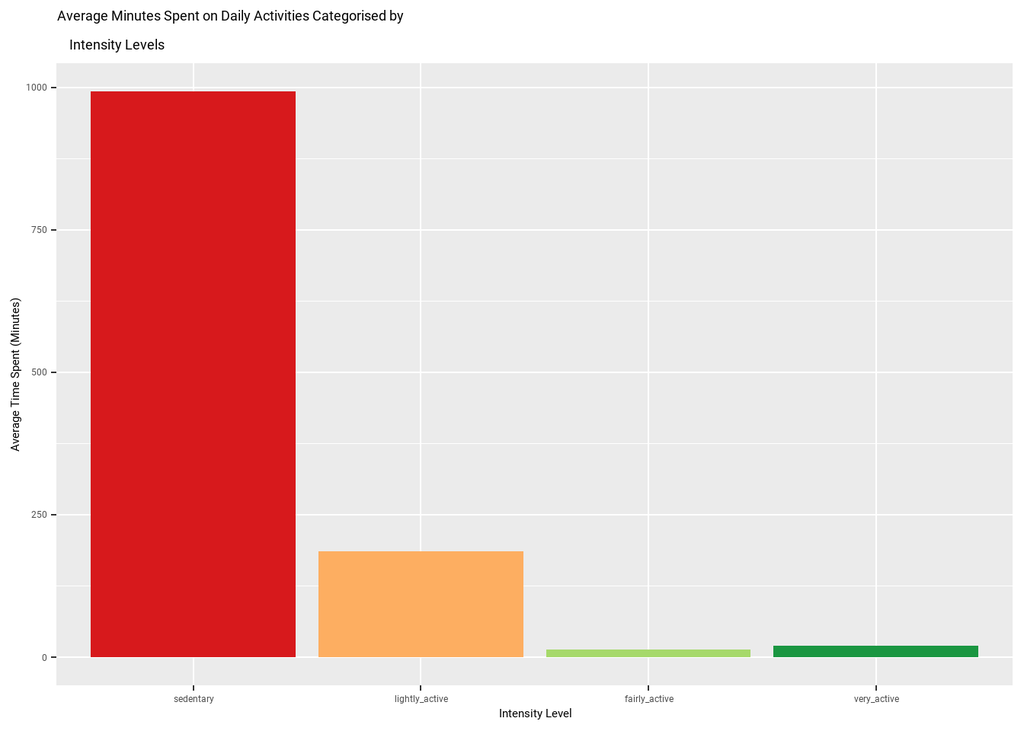

```r
activity_durations <- daily_activity %>%
  select(id,
         very_active_minutes,
         fairly_active_minutes,
         lightly_active_minutes,
         sedentary_minutes) %>%
  group_by(id) %>%
  pivot_longer(cols = ends_with("_minutes"), names_to = "intensity", values_to = "duration") %>%
  mutate(intensity = str_replace(intensity,"_minutes","")) %>%
  group_by(intensity) %>%
  summarise(average_minutes = mean(duration)) %>%
  mutate(intensity = factor(intensity,
                            levels = c("sedentary",
                            "lightly_active",
                            "fairly_active",
                            "very_active")))

ggplot(
  data = activity_durations,
  aes(
    x = intensity,
    y = average_minutes,
    fill = intensity)) +
  geom_col() +
  labs(
    title = "Average Minutes Spent on Daily Activities Categorised by\
    Intensity Levels",
    x = "Intensity Level",
    y = "Average Time Spent (Minutes)") +
  theme(
    legend.position = "none",
    text = element_text(family="roboto")) +
  scale_fill_brewer(palette="RdYlGn")
```

As above figure shows user spent most time being sedentary and lightly active. However, due to the fact the sleeping time will be count as sedentary activity, it cannot show a significant trend of user activity.

### Activity Recommendation by WHO

We can also look into [WHO recommendation of activity level](https://www.who.int/news-room/fact-sheets/detail/physical-activity) for adult to see the activity level of users.

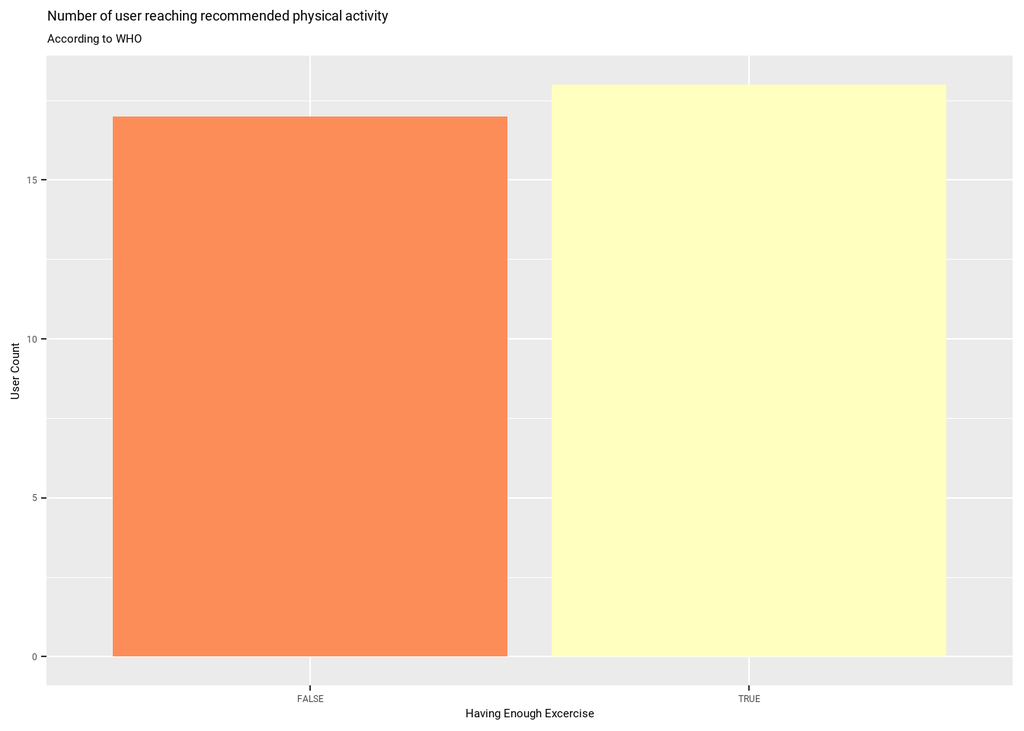

```r
enough_activity <- daily_activity %>%
  select(id,
         date,
         very_active_minutes,
         fairly_active_minutes,
         lightly_active_minutes,
         sedentary_minutes) %>%
  mutate(year = year(date),
         week = week(date)) %>%
  group_by(id, year, week) %>%
  summarise(daily_very_active_mins = sum(very_active_minutes),
            daily_fairly_active_mins = sum(fairly_active_minutes),
            daily_lightly_active_mins = sum(lightly_active_minutes),
            daily_sedentary_minutes = sum(sedentary_minutes),
            .groups="drop") %>%
  group_by(id) %>%
  summarise(avg_very_active_mins = mean(daily_very_active_mins),
            avg_fairly_active_mins = mean(daily_fairly_active_mins),
            avg_lightly_active_mins = mean(daily_lightly_active_mins),
            avg_sedentary_minutes = mean(daily_sedentary_minutes),
            .groups="drop") %>%
  mutate(enough_phy_activity= avg_very_active_mins >= 75 | avg_fairly_active_mins >= 150) %>%
  group_by(enough_phy_activity) %>%
  summarise(user_count = n(),
            .groups="drop")

ggplot(enough_activity, aes(x=enough_phy_activity, y=user_count,fill=enough_phy_activity)) +
  geom_col() +
  labs(
    title = "Number of user reaching recommended physical activity",
    subtitle = "According to WHO",
    x = "Having Enough Excercise",
    y = "User Count",
    fill = "Having Enough Excercise") +
  theme(,
    legend.position = "none",
    text = element_text(family="roboto")) +
  scale_fill_brewer(palette="RdYlGn")
```

We can see the user activeness is spread evenly between having enough and not having enough exercise per week.

### Intensity by hour

Another data set to see the trend of user is minute_activty data frame where we can see a detailed breakdown of the user activity.

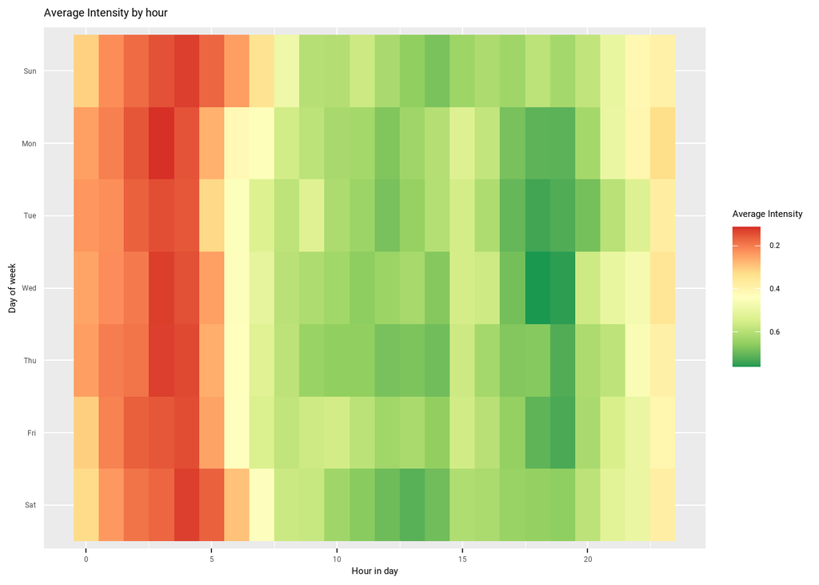

```r
# Create summarised data frame for minute_activity
minute_activities <- minute_activity %>%
  mutate(hour = hour(date_time)) %>%
  mutate(date = date(date_time)) %>%
  group_by(date, hour, id, intensity) %>%
  summarise(total_steps = sum(steps),
            total_calories = sum(calories),
            avg_intensity = mean(intensity),
            .groups = 'drop') %>%
  drop_na() %>%
  mutate(day_of_week = wday(date, label=TRUE)) %>%
  group_by(day_of_week, hour) %>%
  summarise(avg_total_steps = mean(total_steps),
            avg_calories = mean(total_calories),
            avg_intensity = mean(avg_intensity), .groups = 'drop')

ggplot(
  data = minute_activities,
  aes(
    x = hour,
    y = reorder(day_of_week, desc(day_of_week)),
    fill = avg_intensity)) +
  geom_tile() +
  labs(
    title = "Average Intensity by hour",
    x = "Hour in day",
    y = "Day of week",
    fill = "Average Intensity") +
  theme(
    text = element_text(family="roboto"),
    axis.ticks.y = element_blank()) +
  scale_fill_distiller(palette="RdYlGn", trans="reverse")
```

We can see a detailed breakdown of user activity throughout the day.

In the chart above, user tends to have most intense exercise between 1700 to 1900 in weekdays and between 1000 - 1400 in weekend.

However, the average intensity throughout the chart is still between 0 to 1 which means the activity intensity generally fall between sedentary and lightly active.

### Steps taken by users

According to [Healthline](https://www.healthline.com/health/how-many-steps-a-day#how-many-steps-per-day), we can classify activity of user by the steps taken throughout the day.

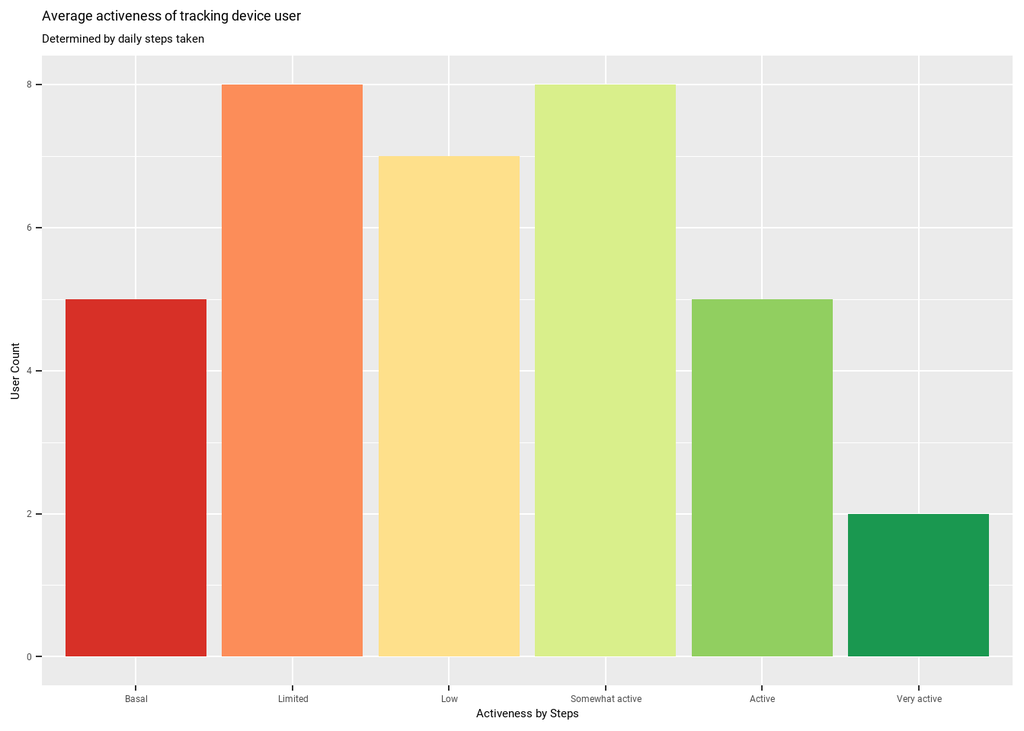

```r
avg_daily_steps <- daily_activity %>%
  select(id,
         total_steps) %>%
  group_by(id) %>%
  summarise(average_total_steps = mean(total_steps)) %>%
  mutate(activeness_by_steps = case_when(
    average_total_steps < 2500 ~ "Basal",
    average_total_steps >= 2500 & average_total_steps <= 4999 ~ "Limited",
    average_total_steps >= 5000 & average_total_steps <= 7499 ~ "Low",
    average_total_steps >= 7500 & average_total_steps <= 9999 ~ "Somewhat active",
    average_total_steps >= 10000 & average_total_steps <= 12499 ~ "Active",
    average_total_steps > 12500 ~ "Very active",
  )) %>%
  mutate(activeness_by_steps = factor(activeness_by_steps,
                                      levels = c("Basal",
                                                 "Limited",
                                                 "Low",
                                                 "Somewhat active",
                                                 "Active",
                                                 "Very active"))) %>%
  group_by(activeness_by_steps) %>%
  summarise(counts = n(), .groups = 'drop')

ggplot(
  data = avg_daily_steps,
  aes(
    x = activeness_by_steps,
    y = counts,
    fill = activeness_by_steps)) +
  geom_bar(stat = "identity") +
  labs(title = "Average activeness of tracking device user",
       subtitle = "Determined by daily steps taken",
       x = "Activeness by Steps",
       y = "User Count") +
  theme(
    legend.position = "none",
    text = element_text(family="roboto")) +
  scale_fill_brewer(palette="RdYlGn")
```

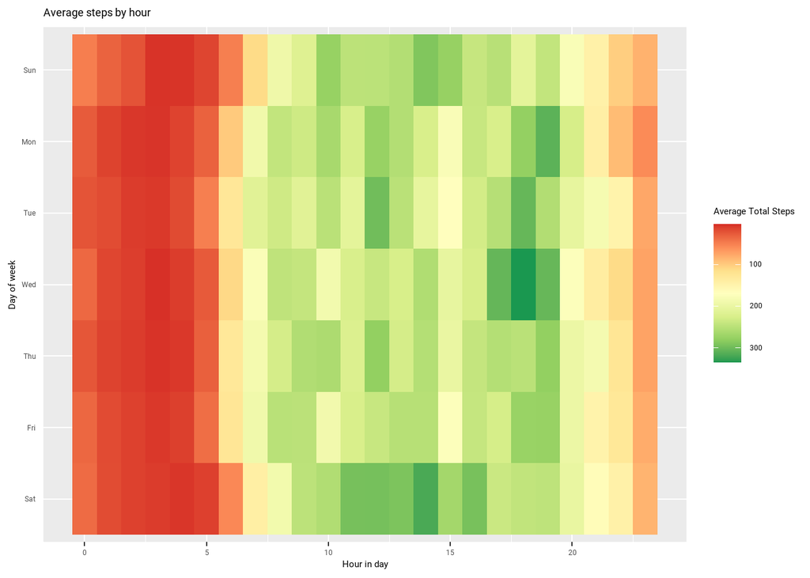

```r
ggplot(
  data = minute_activities,
  aes(
    x = hour,
    y = reorder(day_of_week, desc(day_of_week)),
    fill = avg_total_steps)) +
  geom_tile() +
  labs(
    title = "Average steps by hour",
    x = "Hour in day",
    y = "Day of week",
    fill = "Average Total Steps") +
  theme(
    text = element_text(family="roboto"),
    axis.ticks.y = element_blank()) +
  scale_fill_distiller(palette="RdYlGn", trans="reverse")
```

## Share Phase

According to the above analysis, there are few points to be highlighted:

- Users are equally divided between those who meet WHO recommendations and those who do not.
- However, most of the user are consider not active according to the steps taken.
- The activity intensity and step taken generally increase in weekend and decrease in weekday, during standard office hour.

## Act Phase

Based on this case study, there are several recommendations:

- The marketing team should focus on office working user and promote being active and improve their step count during working hour for better health.
- Notification could be sent to the user to remind and encourage meeting the recommendation of weekly physical activeness.
- An interactive walking challenge in the Bellabeat community can be introduced to inspire users to walk more each day.